# Fitting Ascariasis data

This vignette demonstrates the `AMISforInfectiousDiseases` package through a case study considering Ascariasis in Ethiopia in a single time point. It also shows how to conduct post-processing analysis of the results, e.g. to produce forward projections of prevalence using sub-national estimates of the model parameters.

### Loading packages

```r
library("AMISforInfectiousDiseases")
library("ggplot2")
library("viridis")
```

### Prevalence map

Ascariasis is one of the most common worm infections in people worldwide. This disease is caused by Ascaris lumbricoides, also known as roundworms, which are an intestinal nematode. Ascaris surveys for Ethiopia are available upon request from the Global Atlas of Helminth Infection developed by the London Applied & Spatial Epidemiology Research Group (LASER) (Rachel L et al. 2014). Retkute et al. (2021) used these surveys to obtain national level prevalence maps and made them available as a supplementary material. We will use these maps, which consist of $M=100$ samples of a prevalence map for Ascaris in Ethiopia with 11,369 locations at 10km $\times$ 10km resolution.

In this example, we will use a subset of the data and convert the percentage prevalence values to their decimals. The first two columns of the ascaris data frame are the geographical coordinates (longitude and latitude). The third column contains the observed prevalence in the corresponding location. The remaining columns are the $M=100$ samples from a geostatistical map.

```r
data("ascaris")
wh <- which(ascaris$lon > 36 & ascaris$lon < 40 & ascaris$lat > 5 & ascaris$lat < 12)
ascaris <- ascaris[wh, ]
ascaris[,-c(1,2)] <- ascaris[,-c(1,2)]/100
ascaris_obs_prev <- ascaris[, 1:3]
ascaris_map <- ascaris[, -(1:3)]
L <- nrow(ascaris_map)
```

### Model

Following Anderson and May (1991), we assume that the number of worms $X$ per host has negative binomial distribution NB($W$,$k$), where $W$ is the mean number of worms and $k$ the dispersion parameter describing the degree of clumping of parasites. The probability mass function is given by
$$\begin{equation}
\text{Pr}(X=x) = \frac{\Gamma(x+k)}{\Gamma(k)x!}
\left(\frac{k}{k+W}\right)^k \left(\frac{W}{k+W}\right)^x, \quad
x=0,1,2,\dots.
\end{equation}$$

Therefore, the prevalence is given by the probability of observing worms:

$$\begin{align}
P &= 1 - \text{Pr}\big(X=0 \ \vert \ W, k \big)\\
&= 1 - \left( 1 + \frac{W}{k} \right)^{-k}.
\end{align}$$

In this example, the natural logarithm of the model parameter $W$ is sampled. Thus, the model passed to function `amis` is given by

```r
ascaris_model <- function(seeds, params, n_tims=1){
  p <- matrix(NA, nrow=nrow(params), ncol=n_tims)
  for(t in 1:n_tims){
    W <- exp(params[,1])
    k <- params[,2]
    p[,t] <- 1-(1+W/k)^(-k)
  }
  return(p)
}
```

### Priors

The priors from Retkute et al. (2021) for the model parameters are borrowed in this example. These priors reflect what is currently known about the interaction between the worm burden and clumping coefficient based on the literature. In summary, a uniform prior is placed on the log worm burden and the relationship between the clumping coefficient and worm burden is estimated through a linear regression. Formally this is
$$\begin{align}
\log(W) &\sim U\big(\log(0.01), \log(60)\big), \\
k | W &\sim N\left(\hat{\alpha}+ \hat{\beta} W,
\sigma(W)^2\right), \\
\end{align}$$
where $\hat{\alpha}$ and $\hat{\beta}$ are the intercept and slope coefficients respectively for the regression line of worm burden against the clumping coefficient, and $\sigma(W)$ is five times the standard error from this analysis. Refer to Retkute et al. (2021) for further details on the prior selection.

The prior object passed to `amis()` is given by

```r
fit.v <- c(0.33371009, 0.01719462)
fit.inflation.factor <- 5
fit.hess<-matrix(0, nrow = 2, ncol = 2)
fit.hess[[1,1]] <- 5138.97
fit.hess[[1,2]] <- 49499.4
fit.hess[[2,1]] <- 49499.4
fit.hess[[2,2]] <- 677831

rprior <- function(n) {
  params <- matrix(NA,n,2)
  colnames(params) <- c("logW","k")
  params[,1] <- runif(n,log(0.01),log(60))
  params[,2] <- sapply(1:n, function(i) {
    rnorm(1, mean = fit.v[1] + fit.v[2]*exp(params[i,1]),
          sd = fit.inflation.factor*sqrt(c(1,exp(params[i,1]))%*%solve(fit.hess,c(1,exp(params[i,1])))))
  })
  return(params)
}

dprior <- function(x, log=FALSE) {
  if (log) {
    dlogW <- dunif(x[1],log(0.01),log(60),log=T)
    dk <- dnorm(x[2], mean = fit.v[1] + fit.v[2]*exp(x[1]),
               sd = fit.inflation.factor*sqrt(c(1,exp(x[1]))%*%solve(fit.hess,c(1,exp(x[1])))),log=T)
    return(sum(dlogW,dk))
  } else {
    dlogW <- dunif(x[1],log(0.01),log(60))
    dk <- dnorm(x[2], mean = fit.v[1] + fit.v[2]*exp(x[1]),
               sd = fit.inflation.factor*sqrt(c(1,exp(x[1]))%*%solve(fit.hess,c(1,exp(x[1])))))
    return(prod(dlogW,dk))
  }
}
ascaris_prior <- list(rprior=rprior, dprior=dprior)
```

### Running AMIS

The list of default control parameters can be seen in `default_amis_params()`. This example uses the Gaussian kernel in the nonparametric estimation of the probability density $f$. To use the Gaussian kernel, one needs to define `sigma` in the object `amis_params`. In addition, we will will set model parameter boundaries to ensure that $-\infty < \log(W) < \infty$ and $k>0$.

```r
amis_params <- default_amis_params()
amis_params$boundaries_param <- matrix(c(-Inf, Inf, 0, Inf), 2, 2, byrow=T)
amis_params$sigma <- 0.0025
```

Note that instead of defining boundaries through the object `amis_params`, the user could alternatively set the prevalence to `NA` directly in the model when $k$ is negative and thus out of bounds. The boundaries for prevalence values, which are in $[0,1]$, are taken into account by default (through `amis_params$boundaries`).

Now we have all the objects we need to run the AMIS algorithm:

```r
set.seed(123)
out <- amis(ascaris_map, ascaris_model, ascaris_prior, amis_params)
```

### Analysing AMIS outputs

Given the output returned by `amis()`, we can use the function `print()` to see the data dimensions, model choices, and control parameters used to run the AMIS algorithm. The function `summary()` provides some brief information about the number of samples and effective sample sizes achieved by the algorithm.

```r
print(out)
```

```
#> =============================================================
#> Data description:
#> - Number of locations:  3268
#> - Number of map samples for each location:  100
#> - Number of time points:  1
#> =============================================================
#> Model and algorithm specifications:
#> - For the nonparametric estimation of the density of the likelihood:
#>      Gaussian kernel was used with smoothing parameter sigma = 0.0025
#> - Lower and upper boundaries for prevalences:  0, 1
#> - Number of new samples drawn within each AMIS iteration:  500
#> - Maximum number of iterations:  12
#> - Target effective sample size:  500
```

```r
summary(out)
```

```
#> =============================================================
#> Fitted model:
#> - Number of iterations:  6
#> - Total number of simulated samples:  3000
#> - Target effective sample size:  500
#> Number of locations whose ESS exceeded the target ESS:  3268
#> Number of locations whose ESS was lower the target ESS:  0
```

It is possible to look at the parameter samples proposed at a given iteration (by default, the last iteration) and the corresponding proposal density:

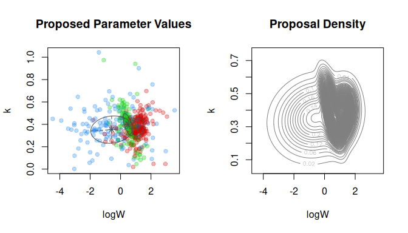

```r
par(mfrow=c(1,2))
plot_mixture_components(out, what = "uncertainty", cex=3)
plot_mixture_components(out, what = "density", nlevels=200)
```

For two arbitrary locations, we show below the posterior distribution of weighted samples for the model parameters and corresponding simulated prevalences.

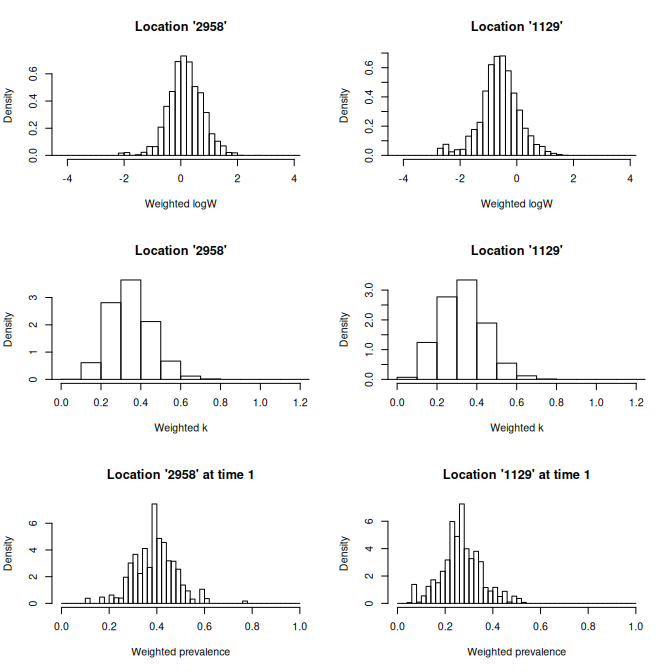

```r
locs <- sample(1:L, 2)
par(mfrow=c(3,2))
plot(out, what = "logW", type="hist", locations=locs, breaks = 50)
plot(out, what = "k", type="hist", locations=locs, breaks = 50)
plot(out, what = "prev", type="hist", locations=locs, time=1, breaks = 50)
```

We can also produce plots of credible intervals for these statistics for all locations as follows:

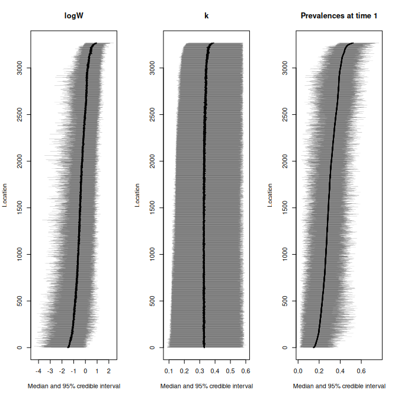

```r
par(mfrow=c(1,3))
plot(out, what=c("logW","k","prev"), type="CI", locations=1:L,
     cex=0.1, lwd=0.1, measure_central="median", order_locations_by="prev")
```

To obtain the numerical values of summary statistics for specific locations, we can run

```r
calculate_summaries(out, what="prev", time=1, locations=locs, alpha=0.05)
```

```
#> $mean
#>   2958   1129
#> 0.3907 0.2677
#>
#> $median
#>   2958   1129
#> 0.3943 0.2666
#>
#> $quantiles
#>         2958    1129
#>  2.5% 0.2146 0.07698
#> 97.5% 0.5958 0.45702
#>
#> $exceedance_probability
#>   2958   1129
#> 0.6965 0.1221
```

### Forward projection

To produce projections of future prevalence under different treatment scenarios, we use the function `sample_parameters()` to sample 100 parameter vectors from the weighted set of parameters obtained from `out` in each location. The sub-sampled model parameters are then fed into the model.

```r
sampled_pars <- sample_parameters(x=out, n_samples=100, locations=1:nrow(ascaris_map))

ascaris_model_with_treatment <- function(params, n_treat_years){
  W <- exp(params[,"logW"]) * 0.9^n_treat_years
  k <- params[,"k"]
  p <- 1-(1+W/k)^(-k)
  return(p)
}
prev_after_treatment <- ascaris_model_with_treatment(params = sampled_pars, n_treat_years = 5)
sampled_pars <- cbind(sampled_pars, prev_after_treatment)
treat_res <- aggregate(prev_after_treatment~location, data=sampled_pars, FUN="median")
```

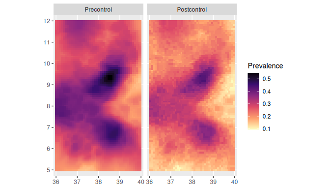

```r
ascaris_proj_prev <- ascaris_obs_prev
ascaris_proj_prev$prevalence <- treat_res$prev_after_treatment
data_proj <- rbind(cbind(type="Precontrol",ascaris_obs_prev),
                  cbind(type="Postcontrol",ascaris_proj_prev))
data_proj$type <- factor(data_proj$type, levels=c("Precontrol","Postcontrol"))
data_proj_sf <- sf::st_as_sf(data_proj, coords = c("lon", "lat"))

ggplot(data=data_proj_sf) +
  geom_sf(aes(colour=prevalence),shape=15,size=3) +
  facet_wrap(~type) +
  scale_colour_gradientn(colours=rev(viridis::magma(6)),
                         name="Prevalence")
```

### References

Anderson, Roy M, and Robert M May. 1991. *Infectious Diseases of Humans: Dynamics and Control*. Oxford university press.

Rachel L, Pullan, Smith Jennifer L, Rashmi Jasrasaria, and Simon J. Brooker. 2014. “Global Numbers of Infection and Disease Burden of Soil Transmitted Helminth Infections in 2010.” *Parasites & Vectors* 7 (37).

Retkute, Renata, Panayiota Touloupou, María-Gloria Basáñez, T. Déirdre Hollingsworth, and Simon E. F. Spencer. 2021. “Integrating geostatistical maps and infectious disease transmission models using adaptive multiple importance sampling.” *The Annals of Applied Statistics* 15 (4): 1980–98. https://doi.org/10.1214/21-AOAS1486.